# Árboles de Regresión en R

# 1. Introducción

- Los métodos de regresión son la herramienta más popular para predicción numérica
- Pero pueden tener problemas
- En particular cuando se tienen muchos predictores
- O cuando existen relaciones complejas (no-lineales) entre outcomes y predictores
- Los árboles de regresión y los modelos de árboles son una alternativa interesante
- Al igual que en clasificación, la esencia está en dividir las observaciones
- De tal forma que pasemos de un grupo grande heterogéneo, a grupos pequeños homogéneos
- La diferencia está en la regla de predicción al llegar a los nodos términales
- En los árboles de regresión, se calcula un promedio
- En los modelos de árbol, se corre una regresión en cada nodo terminal
- Veremos cómo implementar los árboles de regresión en R
- Para ello, usaremos datos de vinos. El objetivo es predecir la calidad de vinos blancos
- La idea es crear un sistema que simule lo que hacen los catadores de vino
- De tal forma que con base en ciertas características de los vinos se prediga su calidad

# 2. Datos

- Usaremos la base `whitewines.csv`, del `UCI Machine Learning Data Repository`
- La base contiene información de diferentes vinos portugueses, incluyendo la calificación de calidad hecha por expertos
- Se incluyen 11 propiedades químicas para 4898 muestras de vino
- Cada muestra fue calificada por un panel de mínimo tres jueces que cataron ciegamente cada uno y calificaron en una escala de 0 a 10
- Carguemos los datos. Como siempre, no olviden fijar el directorio de trabajo

```r
wine<- read.csv("data/whitewines.csv")
```

- En este caso no nos preocupamos por los strings porque todas las variables son numéricas
- Veamos la estructura de los datos:

```r
str(wine)
```

```
## 'data.frame':    4898 obs. of  12 variables:
##  $ fixed.acidity       : num  7 6.3 8.1 7.2 7.2 8.1 6.2 7 6.3 8.1 ...
##  $ volatile.acidity    : num  0.27 0.3 0.28 0.23 0.23 0.28 0.32 0.27 0.3 0.22 ...
##  $ citric.acid         : num  0.36 0.34 0.4 0.32 0.32 0.4 0.16 0.36 0.34 0.43 ...
##  $ residual.sugar      : num  20.7 1.6 6.9 8.5 8.5 6.9 7 20.7 1.6 1.5 ...
##  $ chlorides           : num  0.045 0.049 0.05 0.058 0.058 0.05 0.045 0.045 0.049 0.044 ...
##  $ free.sulfur.dioxide : num  45 14 30 47 47 30 30 45 14 28 ...
##  $ total.sulfur.dioxide: num  170 132 97 186 186 97 136 170 132 129 ...
##  $ density             : num  1.001 0.994 0.995 0.996 0.996 ...
##  $ pH                  : num  3 3.3 3.26 3.19 3.19 3.26 3.18 3 3.3 3.22 ...
##  $ sulphates           : num  0.45 0.49 0.44 0.4 0.4 0.44 0.47 0.45 0.49 0.45 ...
##  $ alcohol             : num  8.8 9.5 10.1 9.9 9.9 10.1 9.6 8.8 9.5 11 ...
##  $ quality             : int  6 6 6 6 6 6 6 6 6 6 ...
```

- Como anticipamos tenemos una base con 4898 muestras de vino y 12 variables, todas numéricas
- Once de ellas son características químicas del vino
- La última, `quality`, es el outcome de interés
- Veamos cómo se distribuye

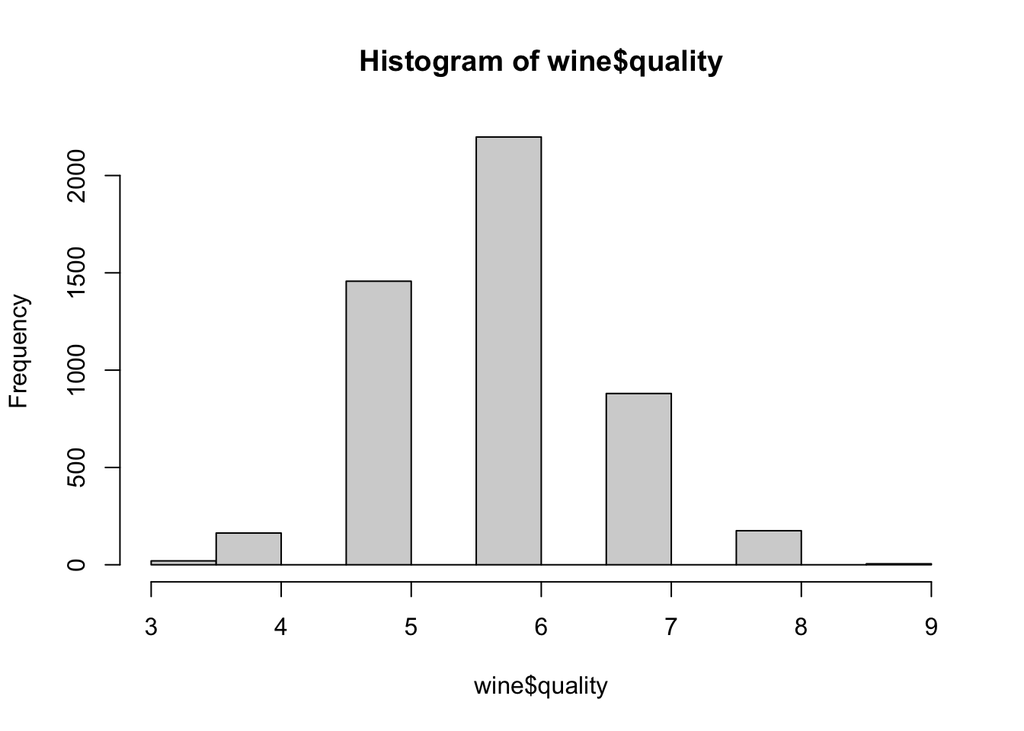

```r
hist(wine$quality)
```

- La distribución es relativamente normal, la mayoría de vinos obtiene 6 de calificación
- Unos pocos son muy malos y unos pocos son muy buenos
- Dividamos nuestra base en dos, para entrenamiento y prueba
- Usaremos 3750 observaciones (~75%) para entrenamiento y el resto para prueba
- Para ello, creemos el vector de números aleatorios

```r
set.seed(123)
train_sample <- sample(4898, 3750)
```

- Y ahora las bases de entrenamiento y prueba

```r
wine_train <- wine[train_sample, ]
wine_test <- wine[-train_sample, ]
```

- Y con esto estamos listos para implementar los modelos

# 3. Árbol de Regresión

- Comencemos entrenando un árbol de regresión
- Para ello usaremos el paquete `rpart`
- Instalémoslo con `install.packages("rpart")` y carguémoslo

```r
library(rpart)
```

```r
m.rpart <- rpart(quality ~ ., data=wine_train)
```

- Si invocamos el modelo, obtenemos alguna información básica:

```r
m.rpart
```

```
## n= 3750
##
## node), split, n, deviance, yval
##       * denotes terminal node
##
##  1) root 3750 2944.81800 5.877600
##    2) alcohol< 10.85 2356 1434.95800 5.601019
##      4) volatile.acidity>=0.2525 1225  596.46200 5.349388 *
##      5) volatile.acidity< 0.2525 1131  676.91950 5.873563
##       10) volatile.acidity>=0.2075 565  278.69030 5.716814 *
##       11) volatile.acidity< 0.2075 566  370.48940 6.030035
##         22) density< 0.99788 473  269.78440 5.917548 *
##         23) density>=0.99788 93   64.27957 6.602151 *
##    3) alcohol>=10.85 1394 1025.03100 6.345050
##      6) free.sulfur.dioxide< 11.5 91   97.95604 5.406593 *
##      7) free.sulfur.dioxide>=11.5 1303  841.33380 6.410591
##       14) alcohol< 11.85 673  416.37440 6.233284 *
##       15) alcohol>=11.85 630  381.20000 6.600000 *
```

- El número de observaciones, la variable y el valor en el que se divide, una medida desviación en el nodo y el pronóstico
- Los nodos con `*` son nodos terminales
- Con la función `summary()` podemos obtener más información, incluyendo medidas de importancia de variables

```r
summary(m.rpart)
```

```
## Call:
## rpart(formula = quality ~ ., data = wine_train)
##   n= 3750
##
##           CP nsplit rel error    xerror       xstd
## 1 0.16463834      0 1.0000000 1.0003515 0.02426688
## 2 0.05486789      1 0.8353617 0.8414378 0.02292559
## 3 0.02911587      2 0.7804938 0.7909701 0.02211455
## 4 0.01485980      3 0.7513779 0.7626422 0.02092328
## 5 0.01089462      4 0.7365181 0.7478875 0.02039433
## 6 0.01000000      6 0.7147289 0.7361845 0.02008999
##
## Variable importance
##              alcohol              density     volatile.acidity
##                   33                   23                   12
##            chlorides total.sulfur.dioxide  free.sulfur.dioxide
##                   11                    8                    5
##       residual.sugar          citric.acid            sulphates
##                    5                    1                    1
##                   pH
##                    1
##
## Node number 1: 3750 observations,    complexity param=0.1646383
##   mean=5.8776, MSE=0.7852849
##   left son=2 (2356 obs) right son=3 (1394 obs)
##   Primary splits:
##       alcohol              < 10.85    to the left,  improve=0.16463830, (0 missing)
##       density              < 0.99201  to the right, improve=0.11559660, (0 missing)
##       chlorides            < 0.0395   to the right, improve=0.08033084, (0 missing)
##       total.sulfur.dioxide < 158.5    to the right, improve=0.04792268, (0 missing)
##       free.sulfur.dioxide  < 11.75    to the left,  improve=0.03711744, (0 missing)
##   Surrogate splits:
##       density              < 0.99201  to the right, agree=0.866, adj=0.639, (0 split)
##       chlorides            < 0.0375   to the right, agree=0.760, adj=0.354, (0 split)
##       total.sulfur.dioxide < 114.5    to the right, agree=0.693, adj=0.174, (0 split)
##       residual.sugar       < 4.65     to the right, agree=0.664, adj=0.095, (0 split)
##       sulphates            < 0.345    to the right, agree=0.641, adj=0.033, (0 split)
##
## Node number 2: 2356 observations,    complexity param=0.05486789
##   mean=5.601019, MSE=0.6090652
```

[output cut: 77 more lines]

```
##   Surrogate splits:
##       residual.sugar < 12.75    to the left,  agree=0.940, adj=0.634, (0 split)
##       alcohol        < 9.15     to the right, agree=0.905, adj=0.419, (0 split)
##
## Node number 14: 673 observations
##   mean=6.233284, MSE=0.6186842
##
## Node number 15: 630 observations
##   mean=6.6, MSE=0.6050794
##
## Node number 22: 473 observations
##   mean=5.917548, MSE=0.5703686
##
## Node number 23: 93 observations
##   mean=6.602151, MSE=0.6911782
```

- De hecho, puede ser más útil visualizar el árbol como tal
- Esto lo hacemos con un paquete aparte: `install.packages("rpart.plot")`

```r
library(rpart.plot)
```

- Y podemos visualizar el árbol:

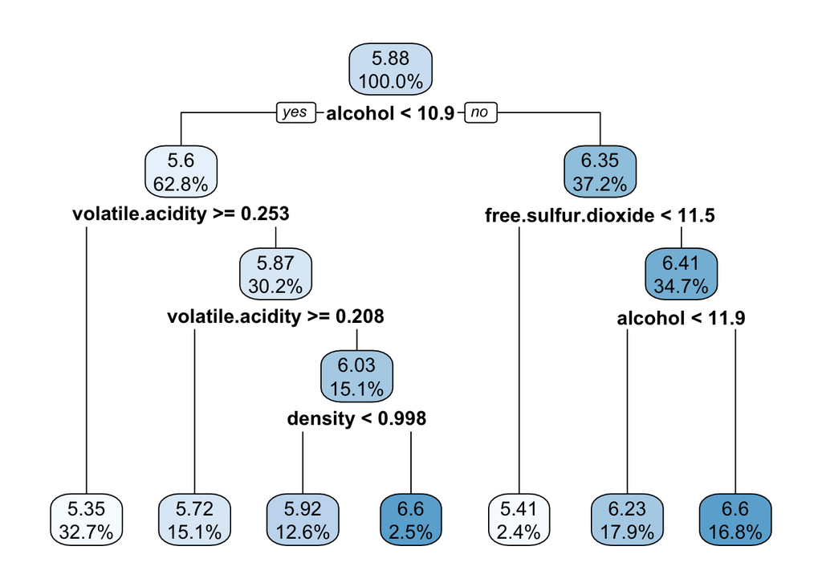

```r
rpart.plot(m.rpart, digits=3)
```

- Como ven, el árbol es bastante elocuente e intuitivo. Nos dice qué porcentaje de casos cae en cada nodo y cuál es la predicción
- Ahora, usando los datos de prueba, podemos evaluar el desempeño del modelo
- Usamos la función `predict()` para ello

```r
p.rpart <- predict(m.rpart, wine_test)
```

- Se ha creado un vector con la calidad pronosticada para cada muestra de vino en el conjunto de prueba

```r
summary(p.rpart)
```

```
##    Min. 1st Qu.  Median    Mean 3rd Qu.    Max.
##   5.349   5.349   5.717   5.868   6.233   6.602
```

- Se ve que hay poca varianza, lo cual es problemático
- Va a ser imposible pronosticar cuáles vinos son muy buenos o muy malos, que los hay en la base de prueba

```r
summary(wine_test$quality)
```

```
##    Min. 1st Qu.  Median    Mean 3rd Qu.    Max.
##   3.000   5.000   6.000   5.879   6.000   8.000
```

- Una primera forma de ver si nuestro modelo lo hace bien es examinando la correlación entre pronósticos y valores reales

```r
cor(p.rpart, wine_test$quality)
```

```
## [1] 0.5084365
```

- Es una correlación alta pero no como para sacar el carro de bomberos
- Necesitamos una medida más precisa del desempeño del modelo
- Usaremos el error absoluto medio (mean absolute error MAE):
- $MAE=\frac{1}{n}\sum_{i=1}^n|e_i|$
- donde $e_i$ es el error de predicción para la observación $i$
- Creemos una función para calcular el MAE

```r
MAE <- function(actual, predicted){
  mean(abs(actual-predicted))
}
```

- Implementemos la función para nuestro modelo:

```r
MAE(p.rpart, wine_test$quality)
```

```
## [1] 0.6080502
```

```r
mean(wine_train$quality)
```

```
## [1] 5.8776
```

```r
MAE(5.8912, wine_test$quality)
```

```
## [1] 0.6665993
```